# Heterogeneity of Treatment Effect analysis pipeline

### Confidence limits for the effect quantiles

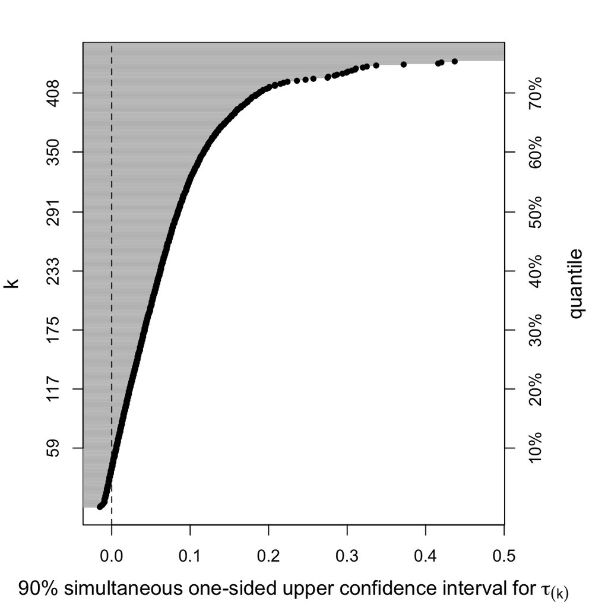

```r
# one-sided upper confidence limits
ci_ub_dr <- cached("ite_onesided_upper_drive_allrows", {
  method_combine(Z = 1 - Z_dr, Y = Y_dr, N = n_dr, k_vec = 1:n_dr, alpha = ALPHA, simul = TRUE,
                 treat.method.list   = list(name = "Stephenson", s = 6),
                 control.method.list = list(name = "Stephenson", s = 6),
                 nperm = NPERM)
})

plot_quantile_bound(-ci_ub_dr$lower[n_dr:1], bound_type = "upper")
```

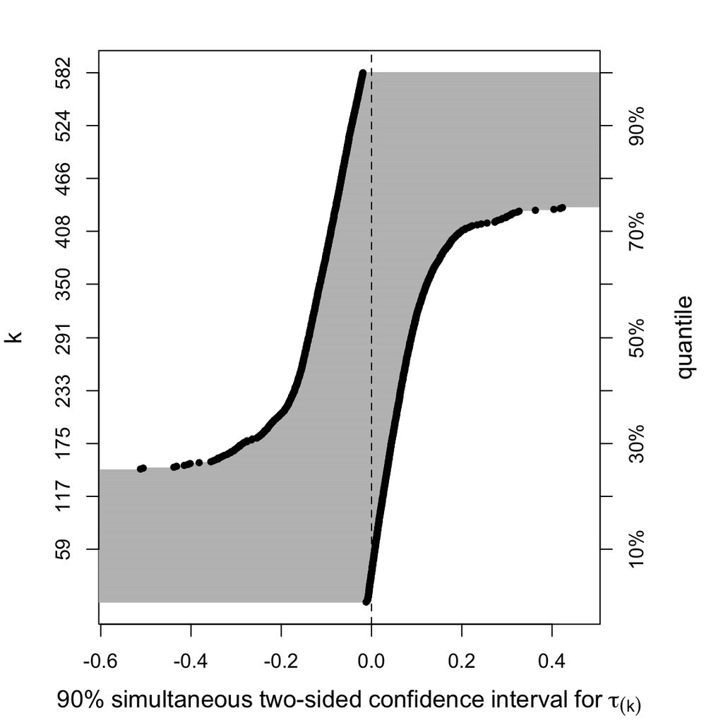

```r
# two-sided confidence intervals
ci_dr <- cached("ite_twosided_drive", {
  lb <- method_combine(Z = Z_dr, Y = Y_dr, N = n_dr, k_vec = 1:n_dr,
                       alpha = ALPHA / 2, simul = TRUE, nperm = NPERM,
                       treat.method.list   = list(name = "Stephenson", s = 6),
                       control.method.list = list(name = "Stephenson", s = 6))
  ub <- method_combine(Z = 1 - Z_dr, Y = Y_dr, N = n_dr, k_vec = 1:n_dr,
                       alpha = ALPHA / 2, simul = TRUE, nperm = NPERM,
                       treat.method.list   = list(name = "Stephenson", s = 6),
                       control.method.list = list(name = "Stephenson", s = 6))
  data.frame(k = 1:n_dr, lower = lb$lower, upper = -ub$lower[n_dr:1])
})

plot_two_sided_CIs(ci_dr$lower, ci_dr$upper)
```

```r
lv_dr  <- c(0.1, 0.25, 0.5, 0.75, 0.9, 1.0)
idx_dr <- ceiling(lv_dr * n_dr)
knitr::kable(
  data.frame(`Quantile level` = paste0(100 * lv_dr, "%"),
             k = idx_dr,
             `Lower limit` = round(ci_dr$lower[idx_dr], 3),
             `Upper limit` = round(ci_dr$upper[idx_dr], 3),
             check.names = FALSE),
  caption = sprintf(
    "%.0f%% two-sided CIs for ITE quantiles, Arm 5 vs Arm 1 (n = %d)",
    100 * (1 - ALPHA), n_dr))
```

90% two-sided CIs for ITE quantiles, Arm 5 vs Arm 1 (n = 582)

| Quantile level | k | Lower limit | Upper limit |
| --- | --- | --- | --- |
| 10% | 59 | -Inf | 0.007 |
| 25% | 146 | -Inf | 0.035 |
| 50% | 291 | -0.140 | 0.088 |
| 75% | 437 | -0.078 | Inf |
| 90% | 524 | -0.044 | Inf |
| 100% | 582 | -0.019 | Inf |

### How many drivers actually reduced their handheld use?

Because lower values indicate improvement, the relevant column is “N with $\tau_i < c$”: the number of drivers whose handheld use fell by at least `-c` of drive time. The thresholds below are on the proportion scale, so `-0.02` is a two percentage point reduction in the share of drive time spent on a handheld phone.

```r
drive_thresholds <- c(0, -0.02, -0.05)

upper_dr <- -ci_ub_dr$lower[n_dr:1]

below_dr <- sapply(drive_thresholds, function(cc) {
  kk <- which(upper_dr < cc); if (length(kk)) max(kk) else 0L })

knitr::kable(
  data.frame(
    `Threshold c`    = drive_thresholds,
    `N with tau < c` = below_dr,
    `% of drivers`   = sprintf("%.1f%%", 100 * below_dr / n_dr),
    check.names = FALSE),
   align = c("l", "l", "r"),
  col.names = c("Threshold $c$", "$N$ with $\\tau_i < c$", "% of drivers"),
  caption = sprintf(
    paste("%.0f%% lower bounds on the NUMBER of drivers with ITE < c (n = %d)"),
    100 * (1 - ALPHA), n_dr))
```

90% lower bounds on the NUMBER of drivers with ITE < c (n = 582)

| Threshold $c$ | $N$ with $\tau_i < c$ | % of drivers |
| --- | --- | --- |
| 0.00 | 37 | 6.4% |
| -0.02 | 0 | 0.0% |
| -0.05 | 0 | 0.0% |

# Appendix.

## Cache status for this knit

Which results were recomputed on this run and which were reloaded from `cache/`.

```r
knitr::kable(cache_report(),
             caption = paste0("Cache status (REFRESH_ALL = ", REFRESH_ALL, ")"))
```

Cache status (REFRESH_ALL = FALSE)

| Result | Status | Seconds |
| --- | --- | --- |
| bcf_fit_binary | reloaded | 0 |
| cate_by_risk_binary | reloaded | 0 |
| causal_forest_binary | reloaded | 0 |
| ite_onesided_lower | reloaded | 0 |
| ite_onesided_upper | reloaded | 0 |
| ite_onesided_upper_drive_allrows | reloaded | 0 |
| ite_twosided | reloaded | 0 |
| ite_twosided_drive | reloaded | 0 |
| prior_results_binary | reloaded | 0 |
| step1_bart_binary | reloaded | 0 |
| vivi_vsup_rd | reloaded | 0 |
| vivi_vsup_rr | reloaded | 0 |
| xgb_slearner_binary | reloaded | 0 |
| xgb_tlearner_binary | reloaded | 0 |